# Project - Practical ML

Mariana Buongermino Pereira

03/01/2021

## Introduction

This report aims to describe how to use ML to determine the activity type based on a data collected throughout the day. The background on the Human Activity Recognition (HAR) project, which has collected the data can be found here: http://groupware.les.inf.puc-rio.br/har.

## Dataset and preprocessing

We were given two data sets:

- pml-training.csv: to create and test the module. This dataset will be split into training and testing.
- pml-testing.csv: new data where we should apply the final model and give predictions. This set will be called new data set. It contains 20 data points.

As a very pragmatic approach to reduce dimensionality, all covariates were not present or or that were NA only in the new dataset were removed. Note that this approach allowed to remove covariates that are derivatives from others, i.e. all kurtosis, skewness, average, etc, which was the desired effect since those are not independent variables.

In addition, all time stamp were discarded and only weekday was kept from all time and date information. As well as all variables with near-zero variability.

```r
data <- read_csv('pml-training.csv', na = c('#DIV/0!', 'NA')) %>%
  select(-X1, -raw_timestamp_part_1, -raw_timestamp_part_2) %>%
  mutate(classe = as.factor(classe), user_name = as.factor(user_name), new_window = as.factor(new_window), cvtd_timestamp = as_datetime(cvtd_timestamp))
data <- data %>%
  mutate(weekday = as.factor(weekdays(cvtd_timestamp))) %>%
  select(-cvtd_timestamp)

newdata <- read_csv('pml-testing.csv', na = c('#DIV/0!', 'NA')) %>%
  select(-X1, -raw_timestamp_part_1, -raw_timestamp_part_2) %>%
  mutate(user_name = as.factor(user_name), new_window = as.factor(new_window), cvtd_timestamp = as_datetime(cvtd_timestamp))
newdata <- newdata %>%
  mutate(weekday = as.factor(weekdays(cvtd_timestamp))) %>%
  select(-cvtd_timestamp)

# Removing columns with NA only
not_all_na <- function(x) any(!is.na(x))
data <- data %>% select_if(not_all_na)
newdata <- newdata %>% select_if(not_all_na)

# Removing columns from data that are not present in newdata
i <- which(names(newdata) == 'problem_id')
colToKeep <- c("classe", names(newdata)[-i])
data <- data %>% select(all_of(colToKeep))

### removing nzv variables
nzv_var <- nearZeroVar(data,saveMetrics = T) %>% filter(nzv == TRUE) %>% row.names()
data <- data %>% select(-all_of(nzv_var))
newdata <- newdata %>% select(-all_of(nzv_var))
```

## Training, Test and Validation sets

The pml-training.csv dataset contained 19622 observations. This dataset was split as

```r
set.seed(42)
inTrain <- createDataPartition(y = data$classe, p = .7, list = F)
training <- data[inTrain,]
testing <- data[-inTrain,]
```

## Modelling

Three different models had their performance compared:

- Regression trees
- Bagging
- Random forest

```r
train_control<- trainControl(method="cv", number=10, savePredictions = TRUE)

### Regression Tree
modRT <- train(classe ~ ., method = 'rpart', data = training, trControl=train_control)

### Bagging
modTB <- train(classe ~ ., method = 'treebag', data = training, trControl=train_control)

### Random Forest
modRF <- train(classe ~ ., data = training, trControl=train_control, method="rf", prox = T)
```

## Results

Model performance has been evaluated on the testing dataset (30% of original data). Since the predicted variable (classe) is categorical, accuracy has been used as measure of performance. Accuracy was computed using the confusionMatrix() command on the testing dataset.

It can be seen that Random Forest and Bagging perform much better than Regression tree, and the reason for that is probably the large number of explanatory variables. The best performing model is Random Forest with 99.8% of accuracy. This corresponds to an out-of-sample error of 1-.998 = 0.2%.

```r
models <- c("Regression Tree", "Bagging", "Random Forest")
acc <- rep(NA, 3)

### Regression tree
acc[1] <- confusionMatrix(testing$classe, predict(modRT, testing))$overall['Accuracy']

### Bagging
acc[2] <- confusionMatrix(testing$classe, predict(modTB, testing))$overall['Accuracy']

### random forest
acc[3] <- confusionMatrix(testing$classe, predict(modRF, testing))$overall['Accuracy']

tibble(models, acc)
```

```
## # A tibble: 3 x 2
##   models            acc
##   <chr>           <dbl>
## 1 Regression Tree 0.523
## 2 Bagging         0.996
## 3 Random Forest   0.998
```

Next, we evaluate what are the most relevant explanatory variables.

```r
varRF <- varImp(modRF)$importance
varImp <- varRF %>% arrange(desc(Overall)) %>% head(n = 10)

varImp
```

```
##                     Overall
## num_window        100.00000
## roll_belt          60.37996
## pitch_forearm      37.72694
## yaw_belt           29.69511
## magnet_dumbbell_z  28.91185
## pitch_belt         27.34482
## magnet_dumbbell_y  27.32464
## roll_forearm       22.55630
## accel_dumbbell_y   12.19489
## magnet_dumbbell_x  11.68267
```

For the two most relevant variables, we can observe correct predictions per classe.

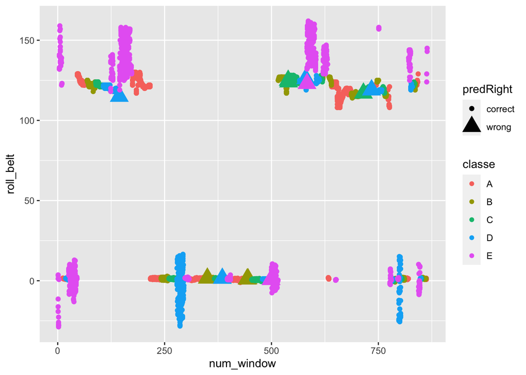

```r
testing <- testing %>%
  mutate(pred = predict(modRF, testing)) %>%
  mutate(predRight = if_else(pred == classe, "correct", "wrong")) %>%
  mutate(predRight = as.factor(predRight))


qplot(num_window, roll_belt, colour = classe, data = testing, shape = predRight, size = predRight)
```

We can also observe the final model error with the inclusion of each tree.

```r
finMod <- modRF$finalModel
finMod
```

```
##
## Call:
##  randomForest(x = x, y = y, mtry = param$mtry, proximity = ..1)
##                Type of random forest: classification
##                      Number of trees: 500
## No. of variables tried at each split: 31
##
##         OOB estimate of  error rate: 0.18%
## Confusion matrix:
##      A    B    C    D    E  class.error
## A 3905    0    0    0    1 0.0002560164
## B    5 2650    3    0    0 0.0030097818
## C    0    4 2392    0    0 0.0016694491
## D    0    0    7 2245    0 0.0031083481
## E    0    1    0    4 2520 0.0019801980
```

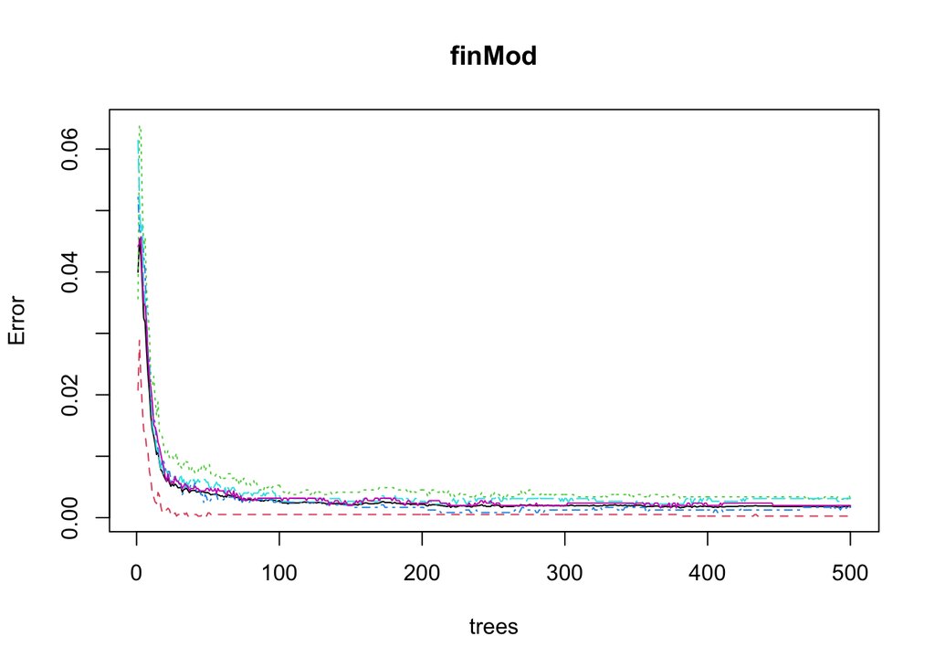

```r
plot(finMod)
```

### New data-set evaluation

The last step is to predict classes to the observations in the new dataset.

```r
newdata_classes <- predict(modelRF, newdata)
```